# Project 1: Math 237

Using the Housing Data set from class, we will explore more of the missing data, create our own variables, and fit a multiple linear regression model to see which features from the data set have to most effect towards a houses selling price.

- Garage
- Basement
- Pool
- Fireplace
- Miscellaneous Feature

```python
# Import libraries
import pandas as pd
import numpy as np
import matplotlib.pyplot as plt
import seaborn as sns
from sklearn.model_selection import train_test_split, cross_val_score, KFold
from sklearn.linear_model import LinearRegression, Ridge
from sklearn.preprocessing import StandardScaler
from sklearn.pipeline import Pipeline
from sklearn.metrics import mean_squared_error, r2_score
```

```python
# Set up plotting
plt.style.use('default')
sns.set_palette("husl")
plt.rcParams['figure.figsize'] = (10, 6)
plt.rcParams['font.size'] = 12

# Make tables display wider
pd.set_option('display.width', 200)
```

Connecting Google Drive and uploading the dataset

```python
# Connect to Google Drive
from google.colab import drive
drive.mount('/content/drive')

print("Google Drive connected!")
```

```
Google Drive connected!
```

```python
# Load the data
data = pd.read_csv('/content/drive/My Drive/Math237/Datasets/ames-housing-train.csv')
# ⚠️⚠️ CHANGE THE PATH TO MATCH YOUR FOLDER ⚠️⚠️
print("Dataset loaded!")
```

```
Dataset loaded!
```

# Part 1

Working on the dataset - dealing with any missing features

```python
data.info()
```

```
<class 'pandas.core.frame.DataFrame'>
RangeIndex: 1460 entries, 0 to 1459
Data columns (total 81 columns):
 #   Column         Non-Null Count  Dtype
---  ------         --------------  -----
 0   Id             1460 non-null   int64
 1   MSSubClass     1460 non-null   int64
 2   MSZoning       1460 non-null   object
 3   LotFrontage    1201 non-null   float64
 4   LotArea        1460 non-null   int64
 5   Street         1460 non-null   object
 6   Alley          91 non-null     object
 7   LotShape       1460 non-null   object
 8   LandContour    1460 non-null   object
 9   Utilities      1460 non-null   object
```

[output cut: 73 more lines]

```python
# Check for missing data
print("Missing values by column:")
missing_counts = data.isnull().sum()
print(missing_counts)
```

```
Missing values by column:
Id                 0
MSSubClass         0
MSZoning           0
LotFrontage      259
LotArea            0
                ...
MoSold             0
YrSold             0
SaleType           0
SaleCondition      0
SalePrice          0
Length: 81, dtype: int64
```

```python
# Checking is we have any complete cases
complete_cases = len(data.dropna())
print(f"Total missing values: {missing_counts.sum()}")
print(f"Complete cases: {complete_cases} out of {len(data)}")
```

```
Total missing values: 7829
Complete cases: 0 out of 1460
```

```python
# Finding how much missing data each variable has
print("MISSING DATA OVERVIEW:")
print("=" * 45)

print(f"\nTotal observations: {len(data)}")
print(f"Complete cases (no missing data): {complete_cases}")
print(f"Percentage of complete cases: {complete_cases / len(data) * 100:.1f}%")

print("\nMissing data by features:")
missing_summary = pd.DataFrame({
    'Missing_Count': data.isnull().sum(),
    'Missing_Percent': (data.isnull().sum() / len(data) * 100).round(1)
})
missing_summary = missing_summary[missing_summary['Missing_Count'] > 0]
print(missing_summary)
```

```
MISSING DATA OVERVIEW:
=============================================

Total observations: 1460
Complete cases (no missing data): 0
Percentage of complete cases: 0.0%

Missing data by features:
              Missing_Count  Missing_Percent
LotFrontage             259             17.7
Alley                  1369             93.8
MasVnrType              872             59.7
MasVnrArea                8              0.5
BsmtQual                 37              2.5
BsmtCond                 37              2.5
BsmtExposure             38              2.6
BsmtFinType1             37              2.5
BsmtFinType2             38              2.6
Electrical                1              0.1
FireplaceQu             690             47.3
GarageType               81              5.5
GarageYrBlt              81              5.5
GarageFinish             81              5.5
GarageQual               81              5.5
GarageCond               81              5.5
PoolQC                 1453             99.5
Fence                  1179             80.8
MiscFeature            1406             96.3
```

## Missing Garage Varibles

We will figuring out why so many features for the garage of these houses are missing

```python
# Investigate garage type data point
print("\nThe samples that are garage type:\n")
garagetype_missing = data[data['GarageType'].isnull()]
print(garagetype_missing)
```

```
The samples that are garage type:

        Id  MSSubClass MSZoning  LotFrontage  LotArea Street Alley LotShape LandContour Utilities  ... PoolArea PoolQC  Fence MiscFeature MiscVal MoSold YrSold  SaleType  SaleCondition  SalePrice
39      40          90       RL         65.0     6040   Pave   NaN      Reg         Lvl    AllPub  ...        0    NaN    NaN         NaN       0      6   2008        WD        AdjLand      82000
48      49         190       RM         33.0     4456   Pave   NaN      Reg         Lvl    AllPub  ...        0    NaN    NaN         NaN       0      6   2009       New        Partial     113000
78      79          90       RL         72.0    10778   Pave   NaN      Reg         Lvl    AllPub  ...        0    NaN    NaN         NaN       0      4   2010        WD         Normal     136500
88      89          50  C (all)        105.0     8470   Pave   NaN      IR1         Lvl    AllPub  ...        0    NaN  MnPrv         NaN       0     10   2009     ConLD        Abnorml      85000
89      90          20       RL         60.0     8070   Pave   NaN      Reg         Lvl    AllPub  ...        0    NaN    NaN         NaN       0      8   2007        WD         Normal     123600
...    ...         ...      ...          ...      ...    ...   ...      ...         ...       ...  ...      ...    ...    ...         ...     ...    ...    ...       ...            ...        ...
1349  1350          70       RM         50.0     5250   Pave  Pave      Reg         Lvl    AllPub  ...        0    NaN    NaN         NaN       0     12   2008        WD         Normal     122000
1407  1408          20       RL          NaN     8780   Pave   NaN      IR1         Lvl    AllPub  ...        0    NaN  MnPrv         NaN       0      3   2009        WD         Normal     112000
1449  1450         180       RM         21.0     1533   Pave   NaN      Reg         Lvl    AllPub  ...        0    NaN    NaN         NaN       0      8   2006        WD        Abnorml      92000
1450  1451          90       RL         60.0     9000   Pave   NaN      Reg         Lvl    AllPub  ...        0    NaN    NaN         NaN       0      9   2009        WD         Normal     136000
1453  1454          20       RL         90.0    17217   Pave   NaN      Reg         Lvl    AllPub  ...        0    NaN    NaN         NaN       0      7   2006        WD        Abnorml      84500

[81 rows x 81 columns]
```

```python
#Are all of the Garage varible missing with Garage Area
garagetype_missing[['GarageType', 'GarageYrBlt','GarageQual', 'GarageCond','GarageArea', 'GarageCars', 'GarageFinish']].head()
```

|  | GarageType | GarageYrBlt | GarageQual | GarageCond | GarageArea | GarageCars | GarageFinish |
| --- | --- | --- | --- | --- | --- | --- | --- |
| 39 | NaN | NaN | NaN | NaN | 0 | 0 | NaN |
| 48 | NaN | NaN | NaN | NaN | 0 | 0 | NaN |
| 78 | NaN | NaN | NaN | NaN | 0 | 0 | NaN |
| 88 | NaN | NaN | NaN | NaN | 0 | 0 | NaN |
| 89 | NaN | NaN | NaN | NaN | 0 | 0 | NaN |

```python
#The number of cases that are missing Garage type and Garage area is zero
print(((data['GarageType'].isnull()) & (data['GarageArea']==0)).sum())
```

```
81
```

We found that the reason there are so many missing varibles invloving the garage are missing is because these houses don't have a garage. So we will fill in these variables with "none" so they are no longer counted as "missing".

```python
#Filling in the missing Garage data
data_imputed = data.copy()

numeric_columns = ['GarageType', 'GarageYrBlt','GarageQual', 'GarageCond', 'GarageFinish']

for col in numeric_columns:
  if data_imputed[col].isnull().any():
    data_imputed[col] = data_imputed[col].fillna('None')
```

## Pool Missing Variable

```python
#Investigating PoolQC data point
poolQC_missing = data[data['PoolQC'].isnull()]
print(poolQC_missing)
```

```
        Id  MSSubClass MSZoning  LotFrontage  LotArea Street Alley LotShape LandContour Utilities  ... PoolArea PoolQC  Fence MiscFeature MiscVal MoSold YrSold  SaleType  SaleCondition  SalePrice
0        1          60       RL         65.0     8450   Pave   NaN      Reg         Lvl    AllPub  ...        0    NaN    NaN         NaN       0      2   2008        WD         Normal     208500
1        2          20       RL         80.0     9600   Pave   NaN      Reg         Lvl    AllPub  ...        0    NaN    NaN         NaN       0      5   2007        WD         Normal     181500
2        3          60       RL         68.0    11250   Pave   NaN      IR1         Lvl    AllPub  ...        0    NaN    NaN         NaN       0      9   2008        WD         Normal     223500
3        4          70       RL         60.0     9550   Pave   NaN      IR1         Lvl    AllPub  ...        0    NaN    NaN         NaN       0      2   2006        WD        Abnorml     140000
4        5          60       RL         84.0    14260   Pave   NaN      IR1         Lvl    AllPub  ...        0    NaN    NaN         NaN       0     12   2008        WD         Normal     250000
...    ...         ...      ...          ...      ...    ...   ...      ...         ...       ...  ...      ...    ...    ...         ...     ...    ...    ...       ...            ...        ...
1455  1456          60       RL         62.0     7917   Pave   NaN      Reg         Lvl    AllPub  ...        0    NaN    NaN         NaN       0      8   2007        WD         Normal     175000
1456  1457          20       RL         85.0    13175   Pave   NaN      Reg         Lvl    AllPub  ...        0    NaN  MnPrv         NaN       0      2   2010        WD         Normal     210000
1457  1458          70       RL         66.0     9042   Pave   NaN      Reg         Lvl    AllPub  ...        0    NaN  GdPrv        Shed    2500      5   2010        WD         Normal     266500
1458  1459          20       RL         68.0     9717   Pave   NaN      Reg         Lvl    AllPub  ...        0    NaN    NaN         NaN       0      4   2010        WD         Normal     142125
1459  1460          20       RL         75.0     9937   Pave   NaN      Reg         Lvl    AllPub  ...        0    NaN    NaN         NaN       0      6   2008        WD         Normal     147500

[1453 rows x 81 columns]
```

```python
#Making sure that the Pool Quality and area match the missing value
print(((data['PoolQC'].isnull()) & (data['PoolArea']==0)).sum())
```

```
1453
```

We found that Pool Quality is missing so many data points is because theses houses don't have a pool to begin with

```python
#Filling in the missing pool quality data points
data_imputed['PoolQC'] = data_imputed['PoolQC'].fillna('None')
```

## Basement Missing Variables

```python
#Investigate basement condition data point
print("\nThe samples that are basement condition:\n")
basementcond_missing = data[data['BsmtCond'].isnull()]
print(basementcond_missing)
```

```
The samples that are basement condition:

        Id  MSSubClass MSZoning  LotFrontage  LotArea Street Alley LotShape LandContour Utilities  ... PoolArea PoolQC  Fence MiscFeature MiscVal MoSold YrSold  SaleType  SaleCondition  SalePrice
17      18          90       RL         72.0    10791   Pave   NaN      Reg         Lvl    AllPub  ...        0    NaN    NaN        Shed     500     10   2006        WD         Normal      90000
39      40          90       RL         65.0     6040   Pave   NaN      Reg         Lvl    AllPub  ...        0    NaN    NaN         NaN       0      6   2008        WD        AdjLand      82000
90      91          20       RL         60.0     7200   Pave   NaN      Reg         Lvl    AllPub  ...        0    NaN    NaN         NaN       0      7   2006        WD         Normal     109900
102    103          90       RL         64.0     7018   Pave   NaN      Reg         Bnk    AllPub  ...        0    NaN    NaN         NaN       0      6   2009        WD         Alloca     118964
156    157          20       RL         60.0     7200   Pave   NaN      Reg         Lvl    AllPub  ...        0    NaN    NaN         NaN       0      6   2006        WD         Normal     109500
182    183          20       RL         60.0     9060   Pave   NaN      Reg         Lvl    AllPub  ...        0    NaN  MnPrv         NaN       0      6   2007        WD         Normal     120000
259    260          20       RM         70.0    12702   Pave   NaN      Reg         Lvl    AllPub  ...        0    NaN    NaN         NaN       0     12   2008        WD         Normal      97000
342    343          90       RL          NaN     8544   Pave   NaN      Reg         Lvl    AllPub  ...        0    NaN    NaN         NaN       0      5   2006        WD         Normal      87500
362    363          85       RL         64.0     7301   Pave   NaN      Reg         Lvl    AllPub  ...        0    NaN    NaN         NaN       0      7   2009     ConLD         Normal     198500
371    372          50       RL         80.0    17120   Pave   NaN      Reg         Lvl    AllPub  ...        0    NaN    NaN         NaN       0      7   2008        WD         Normal     134432
392    393          20       RL          NaN     8339   Pave   NaN      IR1         Lvl    AllPub  ...        0    NaN  MnPrv        Shed    1200      7   2007        WD         Normal     106500
520    521         190       RL         60.0    10800   Pave  Grvl      Reg         Lvl    AllPub  ...        0    NaN    NaN         NaN       0      8   2008        WD         Normal     106250
```

[output cut: 27 more lines]

```python
#Seeing the basement variable are missing with total Basement area being zero
basementcond_missing[['BsmtFinType1','BsmtFinType2', 'BsmtQual', 'BsmtCond', 'BsmtExposure','TotalBsmtSF']].head()
```

|  | BsmtFinType1 | BsmtFinType2 | BsmtQual | BsmtCond | BsmtExposure | TotalBsmtSF |
| --- | --- | --- | --- | --- | --- | --- |
| 17 | NaN | NaN | NaN | NaN | NaN | 0 |
| 39 | NaN | NaN | NaN | NaN | NaN | 0 |
| 90 | NaN | NaN | NaN | NaN | NaN | 0 |
| 102 | NaN | NaN | NaN | NaN | NaN | 0 |
| 156 | NaN | NaN | NaN | NaN | NaN | 0 |

```python
#Finding that the same 37 houses are missing these variables since there is no basement
print(((data['BsmtCond'].isnull()) & (data['TotalBsmtSF']==0)).sum())
```

```
37
```

We found that 37 cases are missing all of the Basement Variables because there is not basement for those house. Meanwhile the variables BsmtExposure and BsmtFinType2 have 1 extra missing data point that is missing completely randomly. (We will deal with those random missing points later)

```python
#Filling in the missing data points for the houses that don't have a basement
numeric_columns_basement = ['BsmtQual', 'BsmtCond', 'BsmtExposure', 'BsmtFinType1', 'BsmtFinType2']

for col in numeric_columns_basement:
  mask = (data_imputed[col].isnull()) & (data_imputed['TotalBsmtSF'] == 0)
  data_imputed.loc[mask, col] = data_imputed.loc[mask, col].fillna('None')
```

## Fire Place Missing Varibles

```python
#Investigating Fireplace data point
FireplaceQu_missing = data[data['FireplaceQu'].isnull()]
print(FireplaceQu_missing)
```

```
        Id  MSSubClass MSZoning  LotFrontage  LotArea Street Alley LotShape LandContour Utilities  ... PoolArea PoolQC  Fence MiscFeature MiscVal MoSold YrSold  SaleType  SaleCondition  SalePrice
0        1          60       RL         65.0     8450   Pave   NaN      Reg         Lvl    AllPub  ...        0    NaN    NaN         NaN       0      2   2008        WD         Normal     208500
5        6          50       RL         85.0    14115   Pave   NaN      IR1         Lvl    AllPub  ...        0    NaN  MnPrv        Shed     700     10   2009        WD         Normal     143000
10      11          20       RL         70.0    11200   Pave   NaN      Reg         Lvl    AllPub  ...        0    NaN    NaN         NaN       0      2   2008        WD         Normal     129500
12      13          20       RL          NaN    12968   Pave   NaN      IR2         Lvl    AllPub  ...        0    NaN    NaN         NaN       0      9   2008        WD         Normal     144000
15      16          45       RM         51.0     6120   Pave   NaN      Reg         Lvl    AllPub  ...        0    NaN  GdPrv         NaN       0      7   2007        WD         Normal     132000
...    ...         ...      ...          ...      ...    ...   ...      ...         ...       ...  ...      ...    ...    ...         ...     ...    ...    ...       ...            ...        ...
1452  1453         180       RM         35.0     3675   Pave   NaN      Reg         Lvl    AllPub  ...        0    NaN    NaN         NaN       0      5   2006        WD         Normal     145000
1453  1454          20       RL         90.0    17217   Pave   NaN      Reg         Lvl    AllPub  ...        0    NaN    NaN         NaN       0      7   2006        WD        Abnorml      84500
1454  1455          20       FV         62.0     7500   Pave  Pave      Reg         Lvl    AllPub  ...        0    NaN    NaN         NaN       0     10   2009        WD         Normal     185000
1458  1459          20       RL         68.0     9717   Pave   NaN      Reg         Lvl    AllPub  ...        0    NaN    NaN         NaN       0      4   2010        WD         Normal     142125
1459  1460          20       RL         75.0     9937   Pave   NaN      Reg         Lvl    AllPub  ...        0    NaN    NaN         NaN       0      6   2008        WD         Normal     147500

[690 rows x 81 columns]
```

```python
#Fireplace quality is missing with fireplaces
FireplaceQu_missing[['FireplaceQu','Fireplaces']].head()
```

|  | FireplaceQu | Fireplaces |
| --- | --- | --- |
| 0 | NaN | 0 |
| 5 | NaN | 0 |
| 10 | NaN | 0 |
| 12 | NaN | 0 |
| 15 | NaN | 0 |

```python
#Making sure the missing fireplace data matches
print(((data['FireplaceQu'].isnull()) & (data['Fireplaces']==0)).sum())
```

```
690
```

The reason there is so many missing data point for the Fireplace quality variable is due to these house have have any fireplaces at all

```python
#Filling in the missing Fireplace data
data_imputed['FireplaceQu'] = data_imputed['FireplaceQu'].fillna('None')
```

## Miscellaneous Features

```python
#Investigating Miscellaneous Features data point
MiscFeature_missing = data[data['MiscFeature'].isnull()]
print(MiscFeature_missing)
```

```
        Id  MSSubClass MSZoning  LotFrontage  LotArea Street Alley LotShape LandContour Utilities  ... PoolArea PoolQC  Fence MiscFeature MiscVal MoSold YrSold  SaleType  SaleCondition  SalePrice
0        1          60       RL         65.0     8450   Pave   NaN      Reg         Lvl    AllPub  ...        0    NaN    NaN         NaN       0      2   2008        WD         Normal     208500
1        2          20       RL         80.0     9600   Pave   NaN      Reg         Lvl    AllPub  ...        0    NaN    NaN         NaN       0      5   2007        WD         Normal     181500
2        3          60       RL         68.0    11250   Pave   NaN      IR1         Lvl    AllPub  ...        0    NaN    NaN         NaN       0      9   2008        WD         Normal     223500
3        4          70       RL         60.0     9550   Pave   NaN      IR1         Lvl    AllPub  ...        0    NaN    NaN         NaN       0      2   2006        WD        Abnorml     140000
4        5          60       RL         84.0    14260   Pave   NaN      IR1         Lvl    AllPub  ...        0    NaN    NaN         NaN       0     12   2008        WD         Normal     250000
...    ...         ...      ...          ...      ...    ...   ...      ...         ...       ...  ...      ...    ...    ...         ...     ...    ...    ...       ...            ...        ...
1454  1455          20       FV         62.0     7500   Pave  Pave      Reg         Lvl    AllPub  ...        0    NaN    NaN         NaN       0     10   2009        WD         Normal     185000
1455  1456          60       RL         62.0     7917   Pave   NaN      Reg         Lvl    AllPub  ...        0    NaN    NaN         NaN       0      8   2007        WD         Normal     175000
1456  1457          20       RL         85.0    13175   Pave   NaN      Reg         Lvl    AllPub  ...        0    NaN  MnPrv         NaN       0      2   2010        WD         Normal     210000
1458  1459          20       RL         68.0     9717   Pave   NaN      Reg         Lvl    AllPub  ...        0    NaN    NaN         NaN       0      4   2010        WD         Normal     142125
1459  1460          20       RL         75.0     9937   Pave   NaN      Reg         Lvl    AllPub  ...        0    NaN    NaN         NaN       0      6   2008        WD         Normal     147500

[1406 rows x 81 columns]
```

```python
#The Number of missing Miscellaneous Features and the value is zero
print(((data['MiscFeature'].isnull()) & (data['MiscVal']==0)).sum())
```

```
1406
```

The Miscellaneous feature column is missing so many data points because the houses don't have any miscellaneous features to begin with

```python
#Filling in missing data
data_imputed['MiscFeature'] = data_imputed['MiscFeature'].fillna('None')
```

After filling all missing data that we can and need we'll check all the missing data that left.

```python
#Checking what missing data is left to deal with
print("Missing data by features:")
missing_summary = pd.DataFrame({
    'Missing_Count': data_imputed.isnull().sum(),
    'Missing_Percent': (data_imputed.isnull().sum() / len(data_imputed) * 100).round(1)
})
missing_summary = missing_summary[missing_summary['Missing_Count'] > 0]
print(missing_summary)
```

```
Missing data by features:
              Missing_Count  Missing_Percent
LotFrontage             259             17.7
Alley                  1369             93.8
MasVnrType              872             59.7
MasVnrArea                8              0.5
BsmtExposure              1              0.1
BsmtFinType2              1              0.1
Electrical                1              0.1
Fence                  1179             80.8
```

```python
#Droping columns that are have to much missing data and we don't need
data_clean = data_imputed.drop(columns=['LotFrontage','Alley','Fence','MasVnrType','MasVnrArea'])
```

```python
#Dropping any rows now with missing data
data_clean= data_clean.dropna()
```

```python
#Checking to make sure we no longer have any missing data in our data set
print("Missing data by features:")
missing_summary = pd.DataFrame({
    'Missing_Count': data_clean.isnull().sum(),
    'Missing_Percent': (data_clean.isnull().sum() / len(data_clean) * 100).round(1)
})
missing_summary = missing_summary[missing_summary['Missing_Count'] > 0]
print(missing_summary)
```

```
Missing data by features:
Empty DataFrame
Columns: [Missing_Count, Missing_Percent]
Index: []
```

After dealing with and cleaning all the missing data from our housing data set we can now move on to the next part of our project

# Part 2

Creating new features in our housing dataset

```python
#Total Sqaure foot of all the porchs combined
data_clean['TotalPorchSF'] = data_clean['OpenPorchSF'] + data_clean['EnclosedPorch'] + data_clean['3SsnPorch'] + data_clean['ScreenPorch'] + data_clean['WoodDeckSF']
```

```python
#Having a feature contain the houses total Sqaure Footage
data_clean['TotalSF'] = data_clean['TotalPorchSF'] + data_clean['TotalBsmtSF'] + data_clean['1stFlrSF'] + data_clean['2ndFlrSF'] + data_clean['GarageArea'] + data_clean['PoolArea'] + data_clean['GrLivArea']
```

```python
#Price of house per sqaure foot
data_clean['PricePerSF'] = data_clean['SalePrice'] / data_clean['TotalSF']
```

```python
#Garage
# 1: yes garage, 0: no garage
data_clean['Garage'] = (data_clean['GarageArea'] > 0).astype(int)
```

```python
#Basement
# 1: yes basement, 0: no basement
data_clean['Bsmt'] = (data_clean['TotalBsmtSF'] > 0).astype(int)
```

```python
#Pool
# 1: yes pool, 0: no pool
data_clean['Pool'] = (data_clean['PoolArea'] > 0).astype(int)
```

```python
#Fireplace
# 1: yes fireplace, 0: no fireplace
data_clean['FireplaceThere'] = (data_clean['Fireplaces'] > 0).astype(int)
```

```python
#Miscellaneous Feature
# 1: yes miscellaneous feature, 0: no miscellaneous feature
data_clean['MiscFeatureThere'] = (data_clean['MiscVal'] > 0).astype(int)
```

# Part 3

Creating our Multivariate Regression Model using our "Luxury" features from our housing data set

## Dropping any columns we won't be using in our model

```python
data_clean = data_clean.drop(columns=['MSZoning', 'Street', 'LotShape', 'LandContour', 'Utilities', 'LotConfig', 'LandSlope', 'Neighborhood', 'Condition1', 'Condition2', 'BldgType', 'HouseStyle'])
```

```python
data_clean = data_clean.drop(columns=['RoofStyle', 'RoofMatl', 'Exterior1st', 'Exterior2nd', 'ExterQual', 'ExterCond', 'Foundation', 'Heating', 'HeatingQC', 'CentralAir'])
```

```python
data_clean = data_clean.drop(columns=['Electrical', 'KitchenQual', 'Functional', 'PavedDrive', 'SaleType', 'SaleCondition', 'Id'])
```

```python
data_clean = data_clean.drop(columns=['YearBuilt', 'YearRemodAdd', 'MSSubClass', 'OverallCond', 'MoSold', 'YrSold', 'LotArea', 'OverallQual', 'KitchenAbvGr', 'TotRmsAbvGrd'], errors='ignore')
```

```python
data_clean = data_clean.drop(columns=['WoodDeckSF', 'OpenPorchSF', 'EnclosedPorch', '3SsnPorch', 'ScreenPorch', 'LowQualFinSF'], errors='ignore')
```

```python
data_clean = data_clean.drop(columns=['BsmtFinSF1', 'BsmtFinSF2', 'BsmtUnfSF', '1stFlrSF', '2ndFlrSF', 'GrLivArea', 'FullBath', 'HalfBath', 'BedroomAbvGr'])
```

```python
print("Remaining columns:")
print(data_clean.columns.tolist())
```

[output not shown]

## Exploring the Data Analysis on the rest of our data

Looking at the basic statistics for our data

```python
# Displaying basic statistics
data_clean.describe()
```

|  | TotalBsmtSF | BsmtFullBath | BsmtHalfBath | Fireplaces | GarageCars | GarageArea | PoolArea | MiscVal | SalePrice | TotalPorchSF | TotalSF | PricePerSF | Garage | Bsmt | Pool | FireplaceThere | MiscFeatureThere |
| --- | --- | --- | --- | --- | --- | --- | --- | --- | --- | --- | --- | --- | --- | --- | --- | --- | --- |
| count | 1457.000000 | 1457.000000 | 1457.000000 | 1457.000000 | 1457.000000 | 1457.000000 | 1457.000000 | 1457.000000 | 1457.000000 | 1457.000000 | 1457.000000 | 1457.000000 | 1457.000000 | 1457.000000 | 1457.000000 | 1457.000000 | 1457.000000 |
| mean | 1056.500343 | 0.425532 | 0.057653 | 0.612903 | 1.765957 | 472.750172 | 2.764585 | 43.578586 | 180851.713109 | 181.469458 | 4738.208648 | 37.766721 | 0.944406 | 0.974605 | 0.004804 | 0.527111 | 0.035690 |
| std | 435.161900 | 0.518987 | 0.238984 | 0.644971 | 0.747336 | 213.750334 | 40.218482 | 496.629946 | 79477.020244 | 156.723287 | 1511.457453 | 7.874254 | 0.229214 | 0.157375 | 0.069171 | 0.499436 | 0.185579 |
| min | 0.000000 | 0.000000 | 0.000000 | 0.000000 | 0.000000 | 0.000000 | 0.000000 | 0.000000 | 34900.000000 | 0.000000 | 668.000000 | 8.081624 | 0.000000 | 0.000000 | 0.000000 | 0.000000 | 0.000000 |
| 25% | 796.000000 | 0.000000 | 0.000000 | 0.000000 | 1.000000 | 330.000000 | 0.000000 | 0.000000 | 129900.000000 | 45.000000 | 3707.000000 | 33.101373 | 1.000000 | 1.000000 | 0.000000 | 0.000000 | 0.000000 |
| 50% | 992.000000 | 0.000000 | 0.000000 | 1.000000 | 2.000000 | 480.000000 | 0.000000 | 0.000000 | 163000.000000 | 164.000000 | 4557.000000 | 37.692628 | 1.000000 | 1.000000 | 0.000000 | 1.000000 | 0.000000 |
| 75% | 1298.000000 | 1.000000 | 0.000000 | 1.000000 | 2.000000 | 576.000000 | 0.000000 | 0.000000 | 214000.000000 | 266.000000 | 5556.000000 | 42.492918 | 1.000000 | 1.000000 | 0.000000 | 1.000000 | 0.000000 |
| max | 6110.000000 | 3.000000 | 2.000000 | 3.000000 | 4.000000 | 1418.000000 | 738.000000 | 15500.000000 | 755000.000000 | 1027.000000 | 19798.000000 | 78.968574 | 1.000000 | 1.000000 | 1.000000 | 1.000000 | 1.000000 |

```python
# Examine the distribution of the Fireplaces feature
data_clean['Fireplaces'].value_counts()
```

| Fireplaces | count |
| --- | --- |
| 0 | 689 |
| 1 | 648 |
| 2 | 115 |
| 3 | 5 |

**dtype:** int64

Creating a Histrogram for the distribution of our target variable: Sale Price

[figure not shown]

```python
#Histrogram of Sale Price
plt.figure(figsize=(10, 6))
plt.hist(data_clean['SalePrice'], bins=15, color='skyblue', alpha=0.7, edgecolor='black')
plt.title('Distribution of Sale Price', fontsize=16)
plt.xlabel('mpg', fontsize=12)
plt.ylabel('Number of Houses', fontsize=12)
plt.grid(True, alpha=0.3)
```

We can see from our histogram that our data is a bit right skewed and tends to be leaning more towards 100,000 to 200,000 in selling prices for our houses.

```python
#Correlation the rest of the data has with our target
correlation_matrix = data_clean.select_dtypes(include=np.number).corr()

print("Correlation with Sale Price (our target):")
print(correlation_matrix['SalePrice'].sort_values(key=abs, ascending=False))
```

```
Correlation with Sale Price (our target):
SalePrice           1.000000
TotalSF             0.802471
PricePerSF          0.667169
GarageCars          0.639966
GarageArea          0.622867
TotalBsmtSF         0.615031
FireplaceThere      0.471599
Fireplaces          0.466762
TotalPorchSF        0.392394
Garage              0.236775
BsmtFullBath        0.226459
Bsmt                0.152783
Pool                0.093825
PoolArea            0.092519
MiscFeatureThere   -0.068249
MiscVal            -0.021126
BsmtHalfBath       -0.016644
Name: SalePrice, dtype: float64
```

Graphs of our target varible with our features

Garage

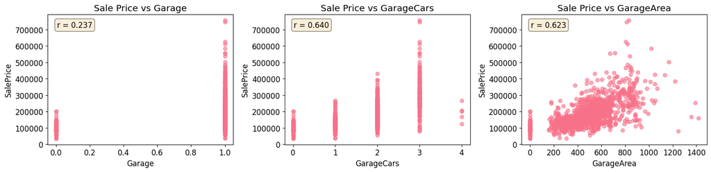

```python
# Scatter plots of Garage features vs Sale Price
features = ['Garage', 'GarageCars', 'GarageArea']
fig, axes = plt.subplots(1, 3, figsize=(16, 4))
axes = axes.flatten()

for idx, feature in enumerate(features):
    axes[idx].scatter(data_clean[feature], data_clean['SalePrice'], alpha=0.6)
    axes[idx].set_xlabel(feature)
    axes[idx].set_ylabel('SalePrice')
    axes[idx].set_title(f'Sale Price vs {feature}')

    corr = data_clean[feature].corr(data_clean['SalePrice'])
    axes[idx].text(0.05, 0.95, f'r = {corr:.3f}',
                   transform=axes[idx].transAxes,
                   verticalalignment='top',
                   bbox=dict(boxstyle='round', facecolor='wheat', alpha=0.5))

plt.tight_layout()
plt.show()
```

Basment

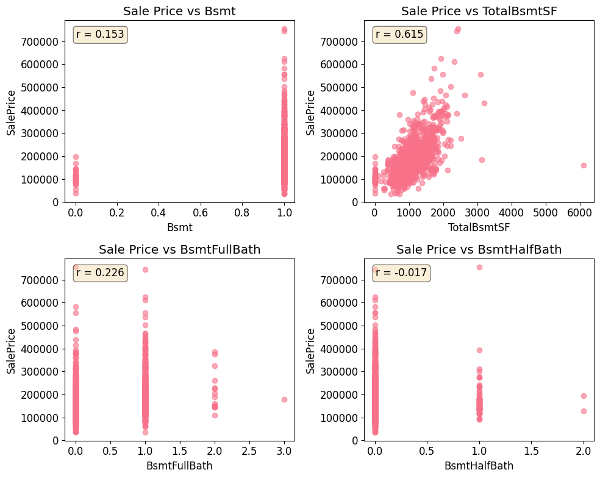

```python
# Scatter plots of Basement features vs Sale Price
features = ['Bsmt', 'TotalBsmtSF', 'BsmtFullBath', 'BsmtHalfBath']
fig, axes = plt.subplots(2, 2, figsize=(10, 8))
axes = axes.flatten()

for idx, feature in enumerate(features):
    axes[idx].scatter(data_clean[feature], data_clean['SalePrice'], alpha=0.6)
    axes[idx].set_xlabel(feature)
    axes[idx].set_ylabel('SalePrice')
    axes[idx].set_title(f'Sale Price vs {feature}')

    corr = data_clean[feature].corr(data_clean['SalePrice'])
    axes[idx].text(0.05, 0.95, f'r = {corr:.3f}',
                   transform=axes[idx].transAxes,
                   verticalalignment='top',
                   bbox=dict(boxstyle='round', facecolor='wheat', alpha=0.5))

plt.tight_layout()
plt.show()
```

Fireplace

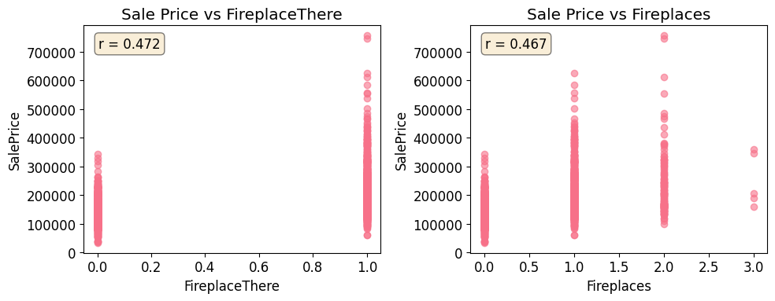

```python
# Scatter plots of Fire Place features vs Sale Price
features = ['FireplaceThere', 'Fireplaces']
fig, axes = plt.subplots(1, 2, figsize=(10, 4))
axes = axes.flatten()

for idx, feature in enumerate(features):
    axes[idx].scatter(data_clean[feature], data_clean['SalePrice'], alpha=0.6)
    axes[idx].set_xlabel(feature)
    axes[idx].set_ylabel('SalePrice')
    axes[idx].set_title(f'Sale Price vs {feature}')

    corr = data_clean[feature].corr(data_clean['SalePrice'])
    axes[idx].text(0.05, 0.95, f'r = {corr:.3f}',
                   transform=axes[idx].transAxes,
                   verticalalignment='top',
                   bbox=dict(boxstyle='round', facecolor='wheat', alpha=0.5))

plt.tight_layout()
plt.show()
```

Pool & Miscellaneous Feature

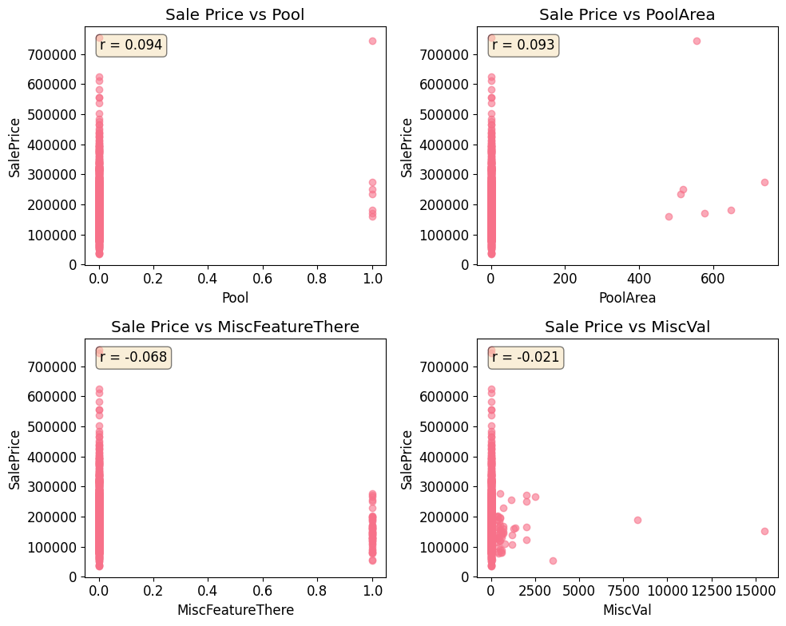

```python
# Scatter plots of Pool & Miscellaneous features vs Sale Price
features = ['Pool', 'PoolArea', 'MiscFeatureThere', 'MiscVal']
fig, axes = plt.subplots(2, 2, figsize=(10, 8))
axes = axes.flatten()

for idx, feature in enumerate(features):
    axes[idx].scatter(data_clean[feature], data_clean['SalePrice'], alpha=0.6)
    axes[idx].set_xlabel(feature)
    axes[idx].set_ylabel('SalePrice')
    axes[idx].set_title(f'Sale Price vs {feature}')

    corr = data_clean[feature].corr(data_clean['SalePrice'])
    axes[idx].text(0.05, 0.95, f'r = {corr:.3f}',
                   transform=axes[idx].transAxes,
                   verticalalignment='top',
                   bbox=dict(boxstyle='round', facecolor='wheat', alpha=0.5))

plt.tight_layout()
plt.show()
```

Other Features

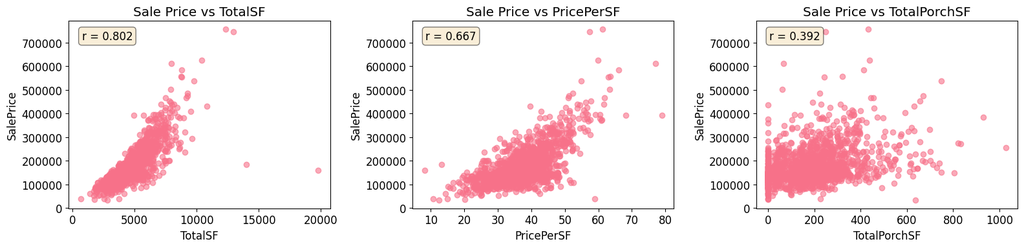

```python
# Scatter plots of other features vs Sale Price
features = ['TotalSF', 'PricePerSF', 'TotalPorchSF']
fig, axes = plt.subplots(1, 3, figsize=(16, 4))
axes = axes.flatten()

for idx, feature in enumerate(features):
    axes[idx].scatter(data_clean[feature], data_clean['SalePrice'], alpha=0.6)
    axes[idx].set_xlabel(feature)
    axes[idx].set_ylabel('SalePrice')
    axes[idx].set_title(f'Sale Price vs {feature}')

    corr = data_clean[feature].corr(data_clean['SalePrice'])
    axes[idx].text(0.05, 0.95, f'r = {corr:.3f}',
                   transform=axes[idx].transAxes,
                   verticalalignment='top',
                   bbox=dict(boxstyle='round', facecolor='wheat', alpha=0.5))

plt.tight_layout()
plt.show()
```

Just by looking at the correlation scatter plots we can see that total square feet, price per square foot, total basement square feet, garage area, and garage cars have high correlation with Sale Price. While Miscellaneous Feature , Miscellaneous feature value, and basement half bath have low correlation with sale price.

## Creating our Multivariate Regression Model

```python
# Defining our features and our target
feature_columns = ['Garage', 'GarageCars', 'GarageArea','Bsmt', 'TotalBsmtSF', 'BsmtFullBath', 'BsmtHalfBath', 'FireplaceThere', 'Fireplaces', 'Pool', 'PoolArea', 'MiscFeatureThere', 'MiscVal','TotalSF', 'PricePerSF', 'TotalPorchSF']

X = data_clean[['Garage', 'GarageCars', 'GarageArea','Bsmt', 'TotalBsmtSF', 'BsmtFullBath', 'BsmtHalfBath', 'FireplaceThere', 'Fireplaces', 'Pool', 'PoolArea', 'MiscFeatureThere', 'MiscVal','TotalSF', 'PricePerSF', 'TotalPorchSF']]
y = data_clean['SalePrice']

print("Feature matrix X shape:", X.shape)
print("Target vector y shape:", y.shape)
```

```
Feature matrix X shape: (1457, 16)
Target vector y shape: (1457,)
```

```python
# Spliting our training and testing sets
X_train, X_test, y_train, y_test = train_test_split( X, y, test_size=0.2, random_state=10)

print(f"Training set size: {len(X_train)} samples")
print(f"Test set size: {len(X_test)} samples")
```

```
Training set size: 1165 samples
Test set size: 292 samples
```

```python
# Calculating the correlation using only the training data
train_data = X_train.copy()
train_data['SalePrice'] = y_train.values

correlation_matrix = train_data.corr()
print("Correlation Matrix (Training Data Only):")
print(correlation_matrix.round(3))
```

```
Correlation Matrix (Training Data Only):
                  Garage  GarageCars  GarageArea   Bsmt  TotalBsmtSF  BsmtFullBath  BsmtHalfBath  FireplaceThere  Fireplaces   Pool  PoolArea  MiscFeatureThere  MiscVal  TotalSF  PricePerSF  \
Garage             1.000       0.571       0.539  0.079        0.173         0.012         0.058           0.194       0.177  0.016     0.016             0.008    0.015    0.258       0.129
GarageCars         0.571       1.000       0.887  0.073        0.456         0.117         0.009           0.345       0.289  0.020     0.019            -0.055   -0.036    0.622       0.358
GarageArea         0.539       0.887       1.000  0.087        0.481         0.165        -0.005           0.300       0.249  0.039     0.037            -0.027   -0.019    0.632       0.306
Bsmt               0.079       0.073       0.087  1.000        0.411         0.133         0.039           0.094       0.086  0.011     0.011            -0.026   -0.003    0.203      -0.001
TotalBsmtSF        0.173       0.456       0.481  0.411        1.000         0.304         0.025           0.316       0.328  0.064     0.061            -0.077   -0.009    0.696       0.271
BsmtFullBath       0.012       0.117       0.165  0.133        0.304         1.000        -0.139           0.078       0.121  0.073     0.072            -0.020   -0.026    0.142       0.250
BsmtHalfBath       0.058       0.009      -0.005  0.039        0.025        -0.139         1.000           0.045       0.039  0.041     0.035             0.031   -0.008    0.020      -0.044
FireplaceThere     0.194       0.345       0.300  0.094        0.316         0.078         0.045           1.000       0.903  0.063     0.063            -0.031   -0.008    0.476       0.233
Fireplaces         0.177       0.289       0.249  0.086        0.328         0.121         0.039           0.903       1.000  0.082     0.080            -0.014    0.002    0.466       0.214
Pool               0.016       0.020       0.039  0.011        0.064         0.073         0.041           0.063       0.082  1.000     0.996             0.057    0.043    0.148      -0.004
PoolArea           0.016       0.019       0.037  0.011        0.061         0.072         0.035           0.063       0.080  0.996     1.000             0.051    0.039    0.141      -0.002
MiscFeatureThere   0.008      -0.055      -0.027 -0.026       -0.077        -0.020         0.031          -0.031      -0.014  0.057     0.051             1.000    0.445   -0.054      -0.070
MiscVal            0.015      -0.036      -0.019 -0.003       -0.009        -0.026        -0.008          -0.008       0.002  0.043     0.039             0.445    1.000   -0.004       0.001
TotalSF            0.258       0.622       0.632  0.203        0.696         0.142         0.020           0.476       0.466  0.148     0.141            -0.054   -0.004    1.000       0.200
PricePerSF         0.129       0.358       0.306 -0.001        0.271         0.250        -0.044           0.233       0.214 -0.004    -0.002            -0.070    0.001    0.200       1.000
TotalPorchSF       0.093       0.239       0.262  0.123        0.310         0.155         0.058           0.289       0.266  0.078     0.073             0.035   -0.003    0.510       0.051
SalePrice          0.239       0.634       0.618  0.155        0.657         0.226        -0.010           0.463       0.452  0.110     0.107            -0.074   -0.016    0.833       0.673

                  TotalPorchSF  SalePrice
Garage                   0.093      0.239
GarageCars               0.239      0.634
GarageArea               0.262      0.618
Bsmt                     0.123      0.155
TotalBsmtSF              0.310      0.657
BsmtFullBath             0.155      0.226
BsmtHalfBath             0.058     -0.010
FireplaceThere           0.289      0.463
Fireplaces               0.266      0.452
Pool                     0.078      0.110
PoolArea                 0.073      0.107
MiscFeatureThere         0.035     -0.074
MiscVal                 -0.003     -0.016
TotalSF                  0.510      0.833
PricePerSF               0.051      0.673
TotalPorchSF             1.000      0.396
SalePrice                0.396      1.000
```

```python
# Creating and fitting the scaler
scaler = StandardScaler()
X_train_scaled = scaler.fit_transform(X_train)
X_test_scaled = scaler.transform(X_test)

# Convert back to DataFrame
X_train_scaled = pd.DataFrame(X_train_scaled, columns=feature_columns, index=X_train.index)
X_test_scaled = pd.DataFrame(X_test_scaled, columns=feature_columns, index=X_test.index)
```

```python
# Creating and training our multivariate regression model
model = LinearRegression()
model.fit(X_train_scaled, y_train)
```

```
LinearRegression()
```

```python
# Extract and display coefficients
intercept = model.intercept_
coefficients = model.coef_

coef_df = pd.DataFrame({
    'Feature': feature_columns,
    'Coefficient': coefficients
}).sort_values('Coefficient', key=abs, ascending=False)

print(f"Intercept (b₀): {intercept:.4f}")
print("\nCoefficients (sorted by absolut value):")
print(coef_df)
```

```
Intercept (b₀): 180767.6429

Coefficients (sorted by absolut value):
             Feature   Coefficient
13           TotalSF  58148.592975
14        PricePerSF  43023.636743
10          PoolArea  10706.049804
9               Pool -10177.247367
7     FireplaceThere  -3312.345736
8         Fireplaces   3147.898815
2         GarageArea   1951.827013
0             Garage  -1592.242233
5       BsmtFullBath  -1572.776200
12           MiscVal  -1513.957201
1         GarageCars  -1381.794060
4        TotalBsmtSF   1078.939289
11  MiscFeatureThere    906.611790
3               Bsmt    707.753976
6       BsmtHalfBath   -275.895586
15      TotalPorchSF    -24.624534
```

```python
# Interpret each coefficient
print("Interpretation of coefficients (on scaled data): \n")

print(f"Intercept: {intercept:.2f}")
print("  Average sale price when all housing features are at their mean values.\n")

for feature, coef in zip(X.columns, coefficients):
    print(f"{feature}: {coef:.2f}")
    print(f"  When {feature} increases by 1 standard deviation,")
    print(f"  sale price increase by {coef:.2f},")
    print(f"  HOLDING OTHER HOUSING FEATURES CONSTANT.\n")
```

```
Interpretation of coefficients (on scaled data):

Intercept: 180767.64
  Average sale price when all housing features are at their mean values.

Garage: -1592.24
  When Garage increases by 1 standard deviation,
  sale price increase by -1592.24,
  HOLDING OTHER HOUSING FEATURES CONSTANT.

GarageCars: -1381.79
  When GarageCars increases by 1 standard deviation,
  sale price increase by -1381.79,
  HOLDING OTHER HOUSING FEATURES CONSTANT.

GarageArea: 1951.83
  When GarageArea increases by 1 standard deviation,
  sale price increase by 1951.83,
  HOLDING OTHER HOUSING FEATURES CONSTANT.

Bsmt: 707.75
  When Bsmt increases by 1 standard deviation,
  sale price increase by 707.75,
  HOLDING OTHER HOUSING FEATURES CONSTANT.

TotalBsmtSF: 1078.94
  When TotalBsmtSF increases by 1 standard deviation,
  sale price increase by 1078.94,
  HOLDING OTHER HOUSING FEATURES CONSTANT.

BsmtFullBath: -1572.78
  When BsmtFullBath increases by 1 standard deviation,
  sale price increase by -1572.78,
  HOLDING OTHER HOUSING FEATURES CONSTANT.

BsmtHalfBath: -275.90
  When BsmtHalfBath increases by 1 standard deviation,
  sale price increase by -275.90,
  HOLDING OTHER HOUSING FEATURES CONSTANT.

```

[output cut: 29 more lines]

```

TotalSF: 58148.59
  When TotalSF increases by 1 standard deviation,
  sale price increase by 58148.59,
  HOLDING OTHER HOUSING FEATURES CONSTANT.

PricePerSF: 43023.64
  When PricePerSF increases by 1 standard deviation,
  sale price increase by 43023.64,
  HOLDING OTHER HOUSING FEATURES CONSTANT.

TotalPorchSF: -24.62
  When TotalPorchSF increases by 1 standard deviation,
  sale price increase by -24.62,
  HOLDING OTHER HOUSING FEATURES CONSTANT.
```

At the end of the day "luxury" feature can hurt or help a house's selling price but they don't carry as much weight as a feature like total square footage does when determining a house's selling price.

## Evaluating our Multivariate Regression Model

```python
# Make predictions on training set
y_train_pred = model.predict(X_train_scaled)

# Calculating metrics
r2_train = r2_score(y_train, y_train_pred)
mse_train = mean_squared_error(y_train, y_train_pred)
rmse_train = np.sqrt(mse_train)

print("Training Set Performance:")
print(f"  R-squared: {r2_train:.4f}")
print(f"  MSE: {mse_train:.4f}")
print(f"  RMSE: {rmse_train:.4f}")
```

```
Training Set Performance:
  R-squared: 0.9625
  MSE: 244337301.5797
  RMSE: 15631.2924
```

```python
# Make predictions on test set
y_test_pred = model.predict(X_test_scaled)

# Calculating metrics
r2_test = r2_score(y_test, y_test_pred)
mse_test = mean_squared_error(y_test, y_test_pred)
rmse_test = np.sqrt(mse_test)

print("Test Set Performance:")
print(f"  R-squared: {r2_test:.4f}")
print(f"  MSE: {mse_test:.4f}")
print(f"  RMSE: {rmse_test:.4f}")
```

```
Test Set Performance:
  R-squared: 0.8345
  MSE: 913048087.8662
  RMSE: 30216.6856
```

```python
# Compare metrics
comparison = pd.DataFrame({
    'Metric': ['R-squared', 'MSE', 'RMSE'],
    'Training': [r2_train, mse_train, rmse_train],
    'Test': [r2_test, mse_test, rmse_test]
})

print(comparison)
```

```
      Metric      Training          Test
0  R-squared  9.624768e-01  8.344925e-01
1        MSE  2.443373e+08  9.130481e+08
2       RMSE  1.563129e+04  3.021669e+04
```

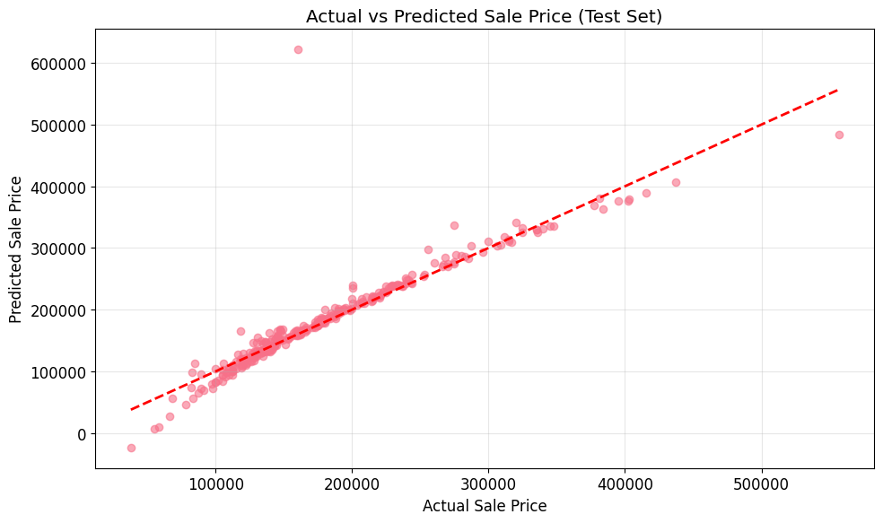

```python
# Plot actual vs predicted values for test set
plt.figure(figsize=(10, 6))
plt.scatter(y_test, y_test_pred, alpha=0.6)
plt.plot([y_test.min(), y_test.max()], [y_test.min(), y_test.max()], 'r--', lw=2)
plt.xlabel('Actual Sale Price')
plt.ylabel('Predicted Sale Price')
plt.title('Actual vs Predicted Sale Price (Test Set)')
plt.grid(True, alpha=0.3)
plt.tight_layout()
plt.show()
```

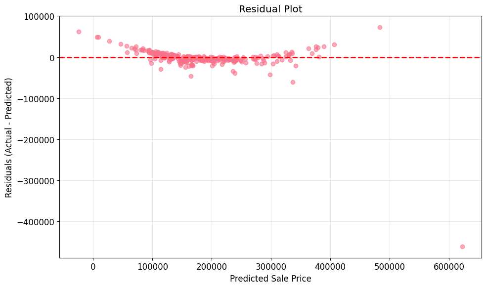

```python
# Plot residuals (prediction errors)
residuals = y_test - y_test_pred

plt.figure(figsize=(10, 6))
plt.scatter(y_test_pred, residuals, alpha=0.6)
plt.axhline(y=0, color='r', linestyle='--', lw=2)
plt.xlabel('Predicted Sale Price')
plt.ylabel('Residuals (Actual - Predicted)')
plt.title('Residual Plot')
plt.grid(True, alpha=0.3)
plt.tight_layout()
plt.show()
```

We can also see that our residual plot isn't exactly linear and is making a bit of an U shaped curve meaning that our model isn't exactly the best to be used when making these predictions.

```python
#%%capture
#Convert this notebook to HTML
#! jupyter nbconvert --to html --no-prompt "/content/drive/My Drive/Math237/ColabNotebooks/Project1.ipynb" --output Project1
```